# Part II - (Investigating Prosper Loans Rates)

## by (Abdulaziz Otaif)

## Investigation Overview

> In this investigation, I explore the different rates associated with loans and how they are effected by each other and other variables, I also explore the investors behaviour and their preferences and how the risk scores change with other variables.

## Dataset Overview

> The prosper loan dataset contains over 100k loan data and has over 80 columns including borrowing rates and yields associated with each loan, loan term and category, borrower data, and even the number of investors in each loan, and many more features.

## (Visualization 1)

> - On average, the borrower APR tend to be the highest for loan listings in the middle of the year, and decreases as aproaching the end of the year.
> - The prosper score tend to be on average the lowest for loan listings in the middle of the year, and increases as aproaching the end of the year.
> - The average number of investors per loan listing tend to be the highest between February and May, and decreases gradually as approaching the end of the year.

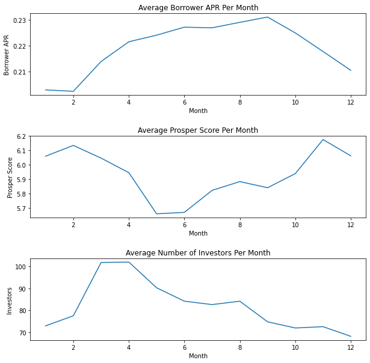

## (Visualization 2)

> Most self-employed borrowers tend to have lower prosper score or higher risk, there are few self-employed borrowers who have high prosper score compared to other types employment status. Full-time employees have the opposite distribution, most full-time employees tend to have higher prosper score or lower risk.

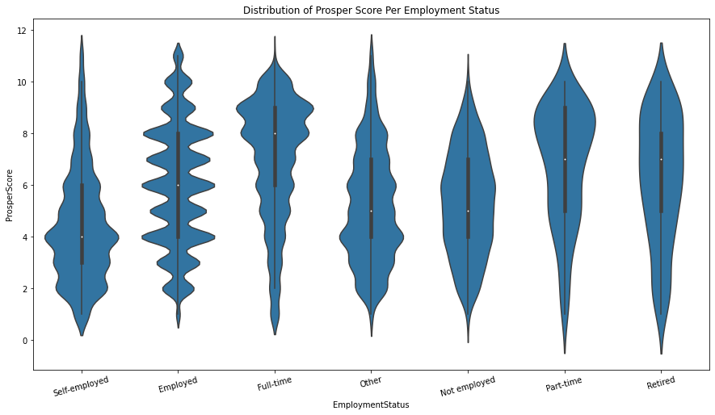

## (Visualization 3)

> Lender yield and the estimated loss are positively correlated, as lender yield go higher, the estimated loss tend to go higher as well.

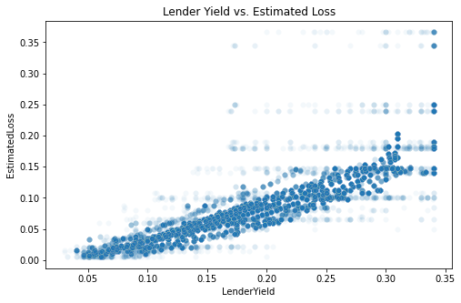

## (Visualization 4)

> Borrowing rates for 12 months loans are the lowest in all listing categories.

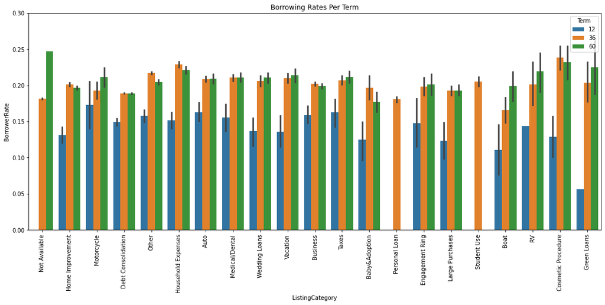

## (Visualization 5)

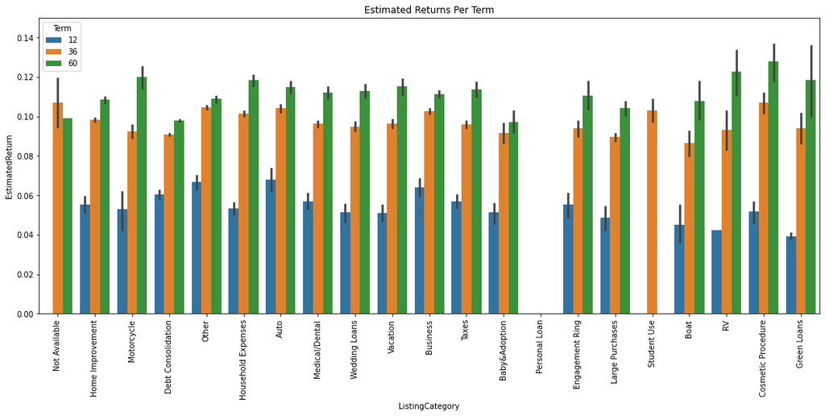

## (Visualization 6)

> - Number of investors in loans borrowed by homeowners is higher than non-homeowners in almost all employment statuses.
> - Borrowing rates are slightly lower for homeowners in all employment statuses except for those who are not employed.

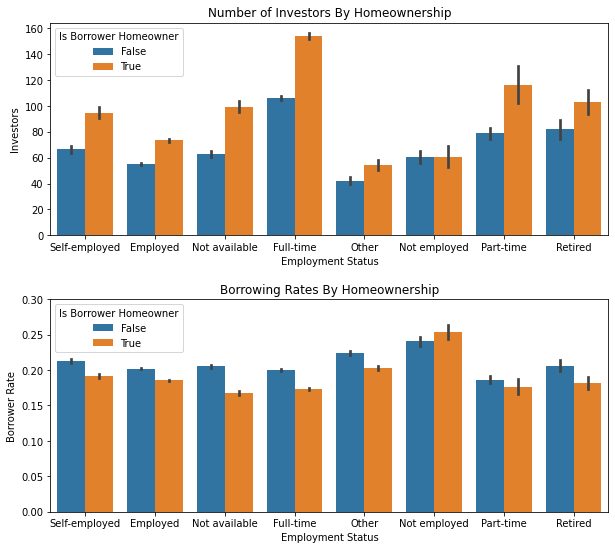